# Memoria caso práctico 2021: La pandemia COVID-19 en España y la influencia de la vacunación

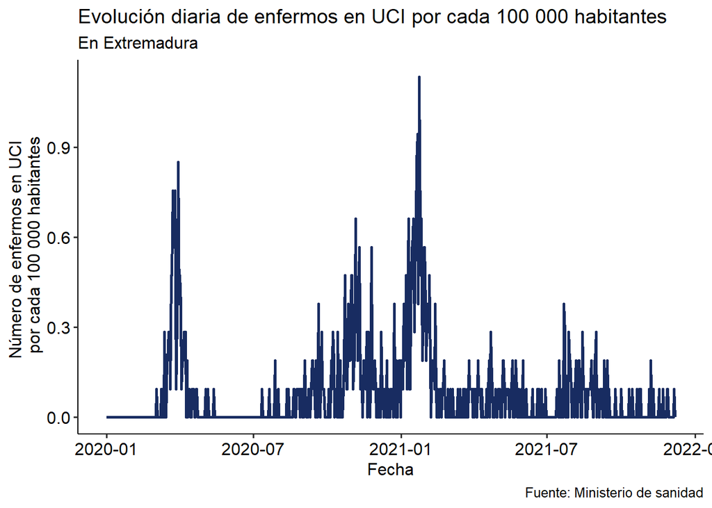

```r
extremadura_casos_hosp_uci$ev100k_num_uci <- (extremadura_casos_hosp_uci$num_uci * 100000) / extremadura_casos_hosp_uci$censo_extremadura #Calculamos el número de hospitalizados por 100 000 habitantes


ggplot(extremadura_casos_hosp_uci, aes(x = fecha, y = ev100k_num_uci)) + geom_line() + geom_line(size = 1, color = "#182C61") + labs(title = "Evolución diaria de enfermos en UCI por cada 100 000 habitantes",
              subtitle = "En Extremadura",
              caption = "Fuente: Ministerio de sanidad",
              x = "Fecha", y = "Número de enfermos en UCI \n por cada 100 000 habitantes")
```

```r
#Creamos una columna de acumulados para cada variable
extremadura_casos_diag_ccaa$acum_num_casos <- cumsum(extremadura_casos_diag_ccaa$num_casos)
extremadura_casos_hosp_uci$acum_num_hosp <- cumsum(extremadura_casos_hosp_uci$num_hosp)
extremadura_casos_hosp_uci$acum_num_uci <- cumsum(extremadura_casos_hosp_uci$num_uci)
extremadura_casos_hosp_uci$acum_num_def <- cumsum(extremadura_casos_hosp_uci$num_def)
```

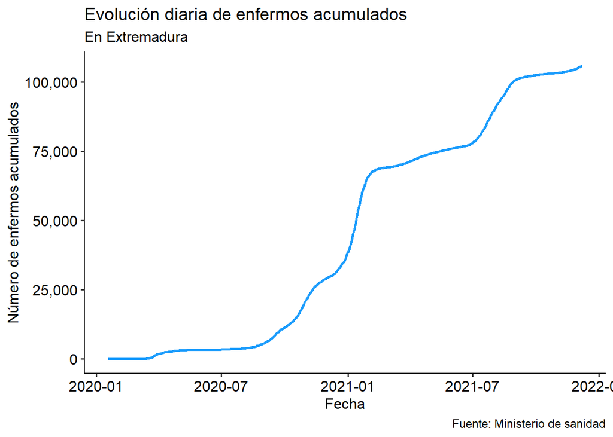

```r
ggplot(extremadura_casos_diag_ccaa, aes(x = fecha, y = acum_num_casos)) + geom_line(size = 1, color = "#1B9CFC") + labs(title = "Evolución diaria de enfermos acumulados",
              subtitle = "En Extremadura",
              caption = "Fuente: Ministerio de sanidad",
              x = "Fecha", y = "Número de enfermos acumulados") + scale_y_continuous(labels = scales::comma)
```

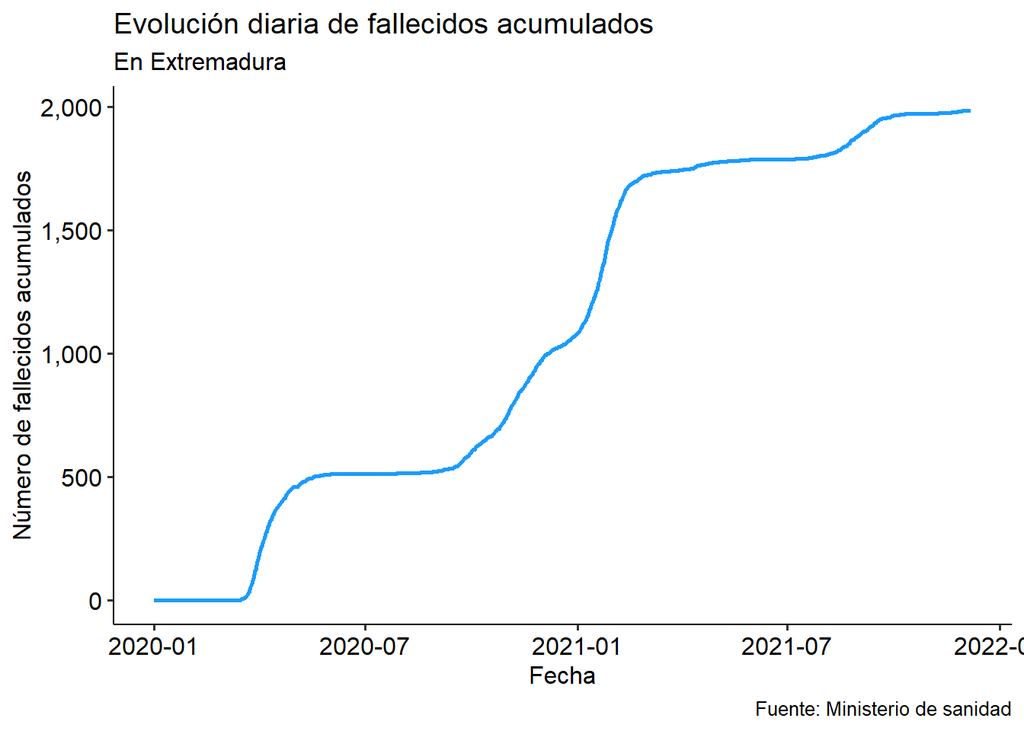

```r
ggplot(extremadura_casos_hosp_uci, aes(x = fecha, y = acum_num_def)) + geom_line(size = 1, color = "#1B9CFC") + labs(title = "Evolución diaria de fallecidos acumulados",
              subtitle = "En Extremadura",
              caption = "Fuente: Ministerio de sanidad",
              x = "Fecha", y = "Número de fallecidos acumulados") + scale_y_continuous(labels = scales::comma)
```

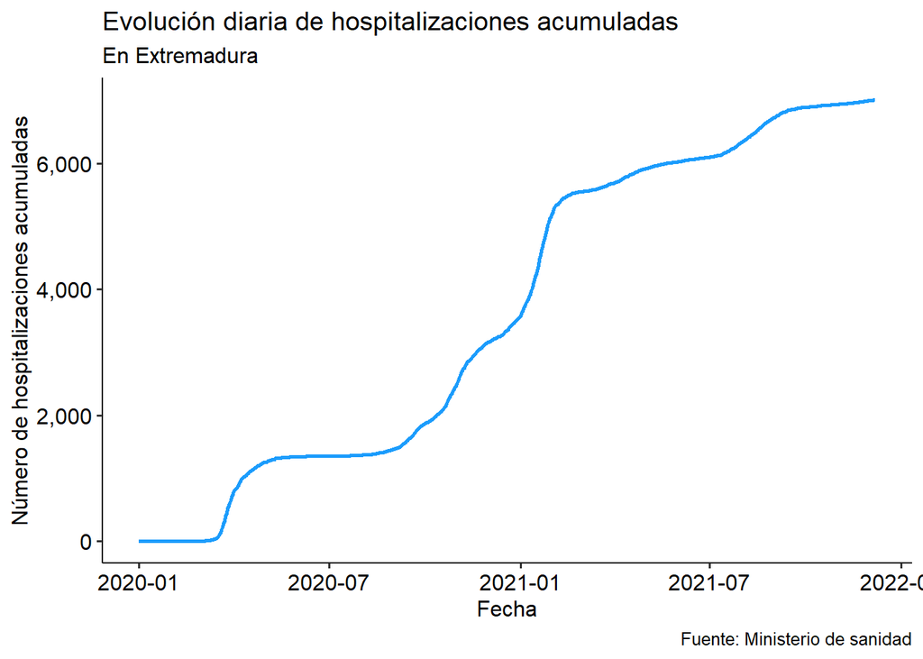

```r
ggplot(extremadura_casos_hosp_uci, aes(x = fecha, y = acum_num_hosp)) + geom_line(size = 1, color = "#1B9CFC") + labs(title = "Evolución diaria de hospitalizaciones acumuladas",
              subtitle = "En Extremadura",
              caption = "Fuente: Ministerio de sanidad",
              x = "Fecha", y = "Número de hospitalizaciones acumuladas") + scale_y_continuous(labels = scales::comma)
```

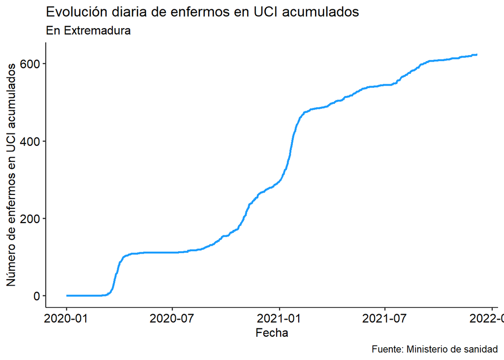

```r
ggplot(extremadura_casos_hosp_uci, aes(x = fecha, y = acum_num_uci)) + geom_line(size = 1, color = "#1B9CFC") + labs(title = "Evolución diaria de enfermos en UCI acumulados",
              subtitle = "En Extremadura",
              caption = "Fuente: Ministerio de sanidad",
              x = "Fecha", y = "Número de enfermos en UCI acumulados") + scale_y_continuous(labels = scales::comma)
```

## 2. Incidencia acumulada de la pandemia en Extremadura

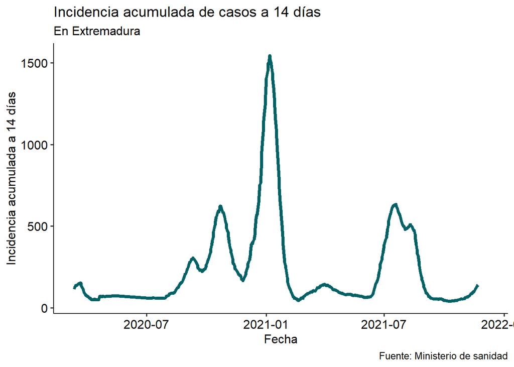

```r
# En la función, t es el número de días transcurridos desde el primer día existente en el dataframe y n el número de días para el que hacer la incidencia acumulada.
iacumuladaex <- function(t, n) {(((ex_incidencia_acumulada_a$acum_num_casos[t]-ex_incidencia_acumulada_a$acum_num_casos[ex_incidencia_acumulada_a$num_fila - n])/ex_incidencia_acumulada_a$censo_ex)*100000)}

ex_incidencia_acumulada_a <- extremadura_casos_diag_ccaa
ex_incidencia_acumulada_a$censo_ex <- c(1057999)
ex_incidencia_acumulada_a <- filter(ex_incidencia_acumulada_a, num_casos > 15)
ex_incidencia_acumulada_a <- ex_incidencia_acumulada_a %>% mutate(num_fila = c(15:(n()+14))) #Creamos una columna que contenga números enteros ordenados desde n hasta llenar la última fila del dataframe

# Suelo utilizar el operador $ para redefinir variables pero en este caso no me queda otra opción que utilizar mutate() de dplyr porque la función n() para introducir los números de fila solamente funciona en las funciones de dplyr.

ex_incidencia_acumulada_a$incidencia_acumulada <- iacumuladaex(ex_incidencia_acumulada_a$num_fila, 14)

ggplot(ex_incidencia_acumulada_a, aes(x = fecha, y = incidencia_acumulada)) + geom_line(size = 1.5, color = "#006266") + labs(title = "Incidencia acumulada de casos a 14 días",
              subtitle = "En Extremadura",
              caption = "Fuente: Ministerio de sanidad",
              x = "Fecha", y = "Incidencia acumulada a 14 días")
```

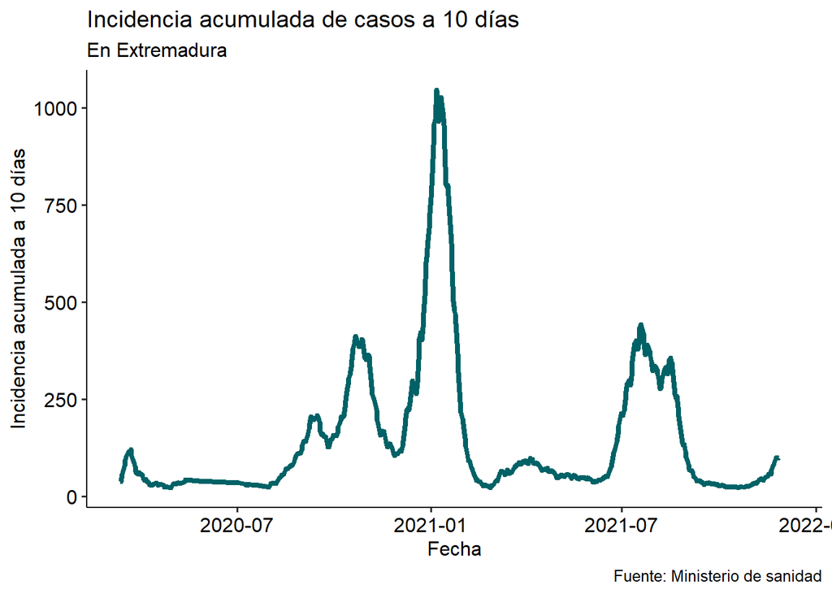

```r
#Redefinimos la función cambiando el dataframe del que cogemos los datos
iacumuladaex <- function(t, n) {(((ex_incidencia_acumulada_b$acum_num_casos[t]-ex_incidencia_acumulada_b$acum_num_casos[ex_incidencia_acumulada_b$num_fila - n])/ex_incidencia_acumulada_b$censo_ex)*100000)}

ex_incidencia_acumulada_b <- extremadura_casos_diag_ccaa
ex_incidencia_acumulada_b$censo_ex <- c(1057999)

ex_incidencia_acumulada_b <- filter(ex_incidencia_acumulada_b, num_casos > 10) #Esta vez filtramos para los valores mayores a 10
ex_incidencia_acumulada_b <- ex_incidencia_acumulada_b %>% mutate(num_fila = c(10:(n()+9))) #Creamos una columna que contenga números enteros ordenados desde n hasta llenar la última fila del dataframe
ex_incidencia_acumulada_b$incidencia_acumulada <- iacumuladaex(ex_incidencia_acumulada_b$num_fila, 10)

ggplot(ex_incidencia_acumulada_b, aes(x = fecha, y = incidencia_acumulada)) + geom_line(size = 1.5, color = "#006266") + labs(title = "Incidencia acumulada de casos a 10 días",
              subtitle = "En Extremadura",
              caption = "Fuente: Ministerio de sanidad",
              x = "Fecha", y = "Incidencia acumulada a 10 días")
```

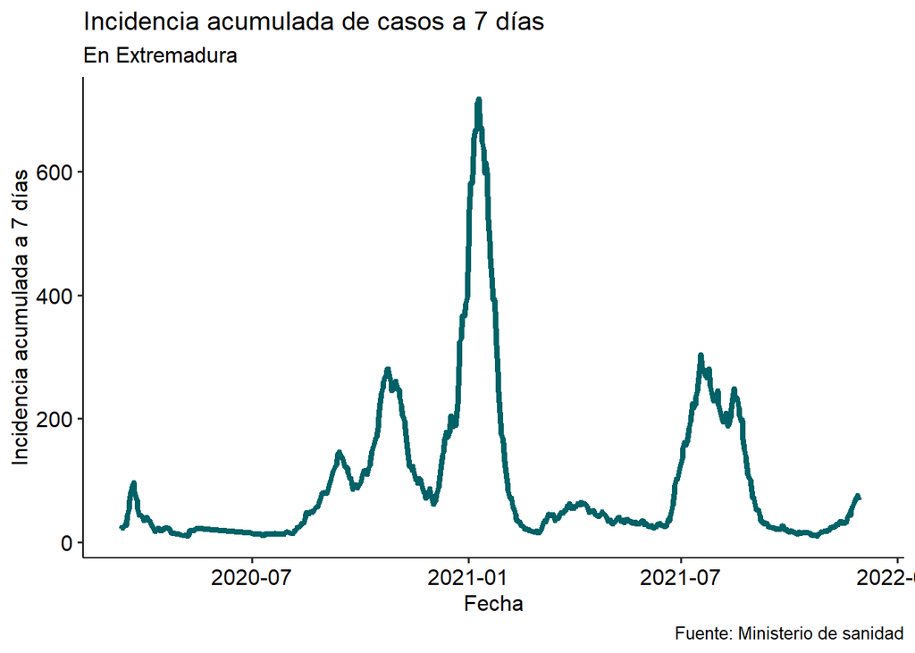

```r
#Redefinimos la función cambiando el dataframe del que cogemos los datos
iacumuladaex <- function(t, n) {(((ex_incidencia_acumulada_c$acum_num_casos[t]-ex_incidencia_acumulada_c$acum_num_casos[ex_incidencia_acumulada_c$num_fila - n])/ex_incidencia_acumulada_c$censo_ex)*100000)}

ex_incidencia_acumulada_c <- extremadura_casos_diag_ccaa
ex_incidencia_acumulada_c$censo_ex <- c(1057999)

ex_incidencia_acumulada_c <- filter(ex_incidencia_acumulada_c, num_casos > 7) #Esta vez filtramos para los valores mayores a 7
ex_incidencia_acumulada_c <- ex_incidencia_acumulada_c %>% mutate(num_fila = c(7:(n()+6))) #Creamos una columna que contenga números enteros ordenados desde n hasta llenar la última fila del dataframe
ex_incidencia_acumulada_c$incidencia_acumulada <- iacumuladaex(ex_incidencia_acumulada_c$num_fila, 7)

ggplot(ex_incidencia_acumulada_c, aes(x = fecha, y = incidencia_acumulada))  + geom_line(size = 1.5, color = "#006266") + labs(title = "Incidencia acumulada de casos a 7 días",
              subtitle = "En Extremadura",
              caption = "Fuente: Ministerio de sanidad",
              x = "Fecha", y = "Incidencia acumulada a 7 días")
```

### 3. Datos de vacunación en Extremadura

```r
extremadura_datosVacunacionGit <- datosVacunacionGit %>% filter(cod_ine == "11") %>% select(-ccaa, -cod_ine, -fecha_de_la_ultima_vacuna_registrada)

# Incorporamos la columna de dosis administradas diarias

extremadura_datosVacunacionGit$dosis_administradas_diarias <- abs(extremadura_datosVacunacionGit$dosis_administradas - lag(extremadura_datosVacunacionGit$dosis_administradas, 1))
extremadura_datosVacunacionGit$dosis_administradas_diarias[1] <- 0 # Sustituimos el valor nulo inicial por 0
```

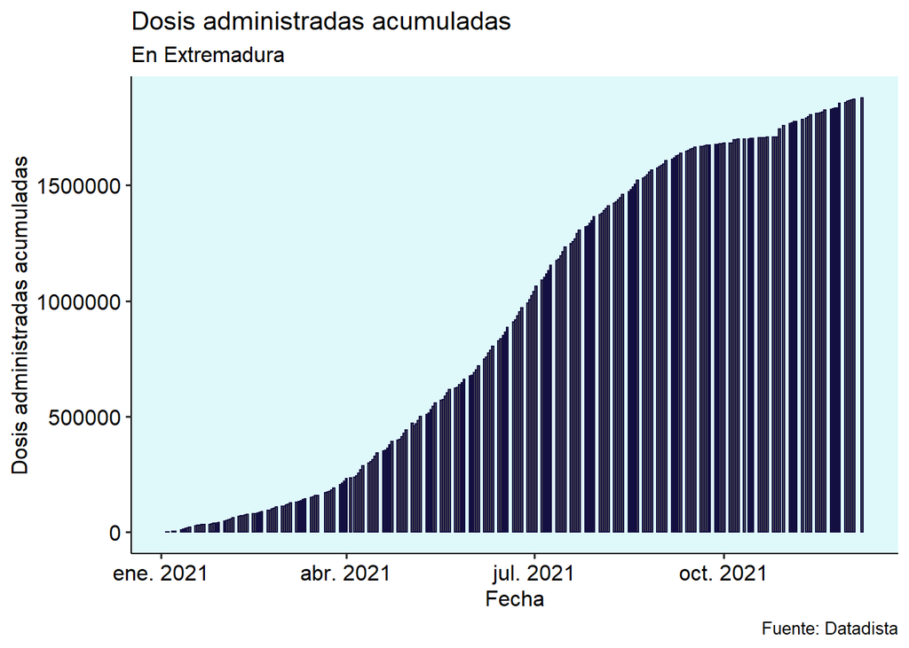

```r
ggplot(extremadura_datosVacunacionGit, aes(x = fecha_publicacion, y = dosis_administradas)) + geom_col(color = "#130f40") + theme(panel.background = element_rect(fill = "#dff9fb", colour = NA), panel.grid.major = element_blank(), panel.grid.minor = element_blank()) + labs(title = "Dosis administradas acumuladas",
              subtitle = "En Extremadura",
              caption = "Fuente: Datadista",
              x = "Fecha", y = "Dosis administradas acumuladas")
```

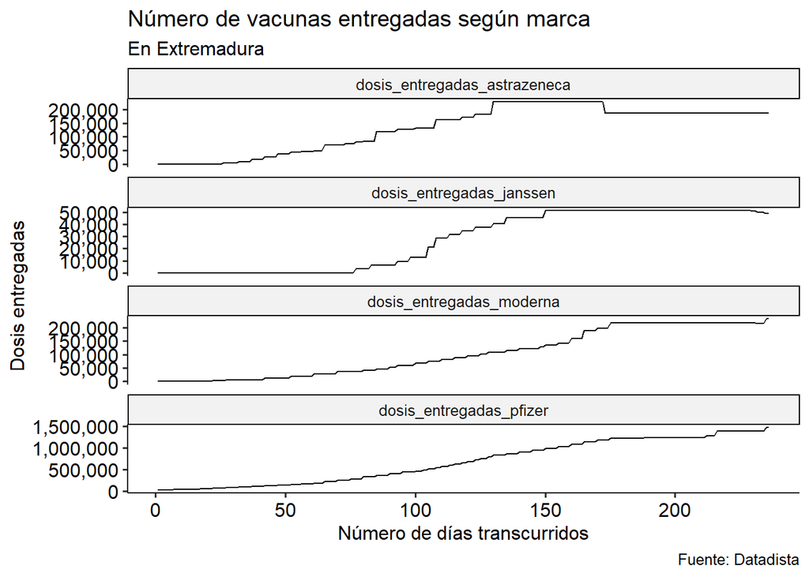

```r
# Después de instalar ggfortify.

library(ggfortify) # Ampliación de las funciones de ggplot2, incluyendo la función que nos hace falta: autoplot()

# Creamos un nuevo objeto basado en tiempo, esto es un cierto número de observaciones distribuidas a lo largo de un período de tiempo determinado y con una frecuencia definida. En este caso utilizaré un objeto ts para el que no será necesario instalar ningún otro paquete. Además puedo convertir mis variables del dataframe de vacunación a objetos ts con la función as.ts(), ya que están basadas en tiempo y son numéricas.

ts_extremadura_datosVacunacionGit <- as.ts(select(extremadura_datosVacunacionGit, dosis_entregadas_astrazeneca, dosis_entregadas_janssen, dosis_entregadas_moderna, dosis_entregadas_pfizer)) #En el objeto ts solamente estarán las variables de dosis entregadas según la marca.
autoplot(ts_extremadura_datosVacunacionGit) + labs(title = "Número de vacunas entregadas según marca",
              subtitle = "En Extremadura",
              caption = "Fuente: Datadista",
              x = "Número de días transcurridos", y = "Dosis entregadas") + scale_y_continuous(labels = scales::comma)
```

```r
# Después de instalar dygraphs y xts

library(dygraphs) # Introduce la librería de dygraphs para Javascript en R, permitiendo crear gráficas interactivas a partir de objetos xts.
library(xts) # Permite crear objetos xts.
xts_extremadura_datosVacunacionGit <- xts(x = extremadura_datosVacunacionGit$dosis_administradas_diarias, order.by = extremadura_datosVacunacionGit$fecha_publicacion)


dygraph(xts_extremadura_datosVacunacionGit, main = "Evolución diaria de la vacunación en Extremadura") %>% dyRangeSelector()
```

[interactive chart not shown]

```r
# En la siguiente gráfica se puede hacer hover sobre los datos para conocer el número de vacunados diarios en un momento determinado. Se puede ajustar el rango de fechas que toma el eje x moviendo los extremos de la barra que hay bajo la gráfica.
```

```r
# Después de instalar fuzzyjoin

library(fuzzyjoin)

ex_vacunacionVScasos <- data.frame("fecha" = extremadura_casos_hosp_uci$fecha, "num_casos" = extremadura_casos_hosp_uci$num_casos) # Creamos el nuevo dataframe que contiene los datos de enfermos acumulados y la columna de fechas de ese dataframe.

ex_vacunacionVScasos <- ex_vacunacionVScasos %>%
  stringdist_inner_join(extremadura_datosVacunacionGit, by = c("fecha" = "fecha_publicacion"), max_dist = 0, distance_col = "distance")
# Al establecer max_dist = 0 solo las coincidencias exactas con la fecha se han copiado. Además he incluido la columna "distance" para poder detectar errores en el caso de que los hubiera, ya que el valor de esta variable siempre debe ser 0 en este caso.

ex_vacunacionVScasos$censo_extremadura <- c(1057999) #Introducimos el censo de Extremadura

ex_vacunacionVScasos <- ex_vacunacionVScasos %>% mutate(enfermos_diarios_por_100hab = (num_casos*100) / censo_extremadura, porcentaje_vacunados = (personas_con_pauta_completa/censo_extremadura)*100) # Creamos las variables que vamos a utilizar en la gráfica mediante operaciones con otras variables.
```

En Extremadura cambiamos los enfermos por 100 000 habitantes a enfermos por cada 100 habitantes.

```r
# Tras haber instalado plotly

library(plotly) # Plotly utiliza la librería plotly.js de Javascript para crear los gráficos interactivos. Ofrece muchas posibilidades, como la creación de animaciones o controles personalizados, por eso es una muy buena opción para las aplicaciones con Shiny.

plotly_ex_vacunacionVScasos <- ggplot(ex_vacunacionVScasos, aes(x = fecha, y = enfermos_diarios_por_100hab)) + geom_line() + geom_line(aes(y = porcentaje_vacunados), color = "red", linetype = "solid") + labs(title = "% de vacunados en comparación con el nº de enfermos por 100 habitantes",
              subtitle = "",
              caption = "Fuente: Ministerio de sanidad y Datadista",
              x = "Fecha", y="") # Creamos la gráfica en ggplot2
plotly_ex_vacunacionVScasos <- ggplotly(plotly_ex_vacunacionVScasos) %>% layout(hovermode = 'x') # La pasamos a gráfica de plotly y establecemos la opción de comparar los datos en la y por defecto.
plotly_ex_vacunacionVScasos
```

[interactive chart not shown]

```r
#Los gráficos de plotly permiten hacer zoom en cualquier parte del gráfico para observar las tendencias con más detenimiento. Al hacer hover aparece la leyenda. Además, se puede descargar el gráfico en png después de modificarlo haciendo clic en el botón de la cámara en la barra de herramientas de la esquina superior derecha.
```

### 4. Datos de mortalidad general en Extremadura

```r
extremadura_gedad_momo_iscii <- filter(momo_iscii, nombre_ambito == "Extremadura", nombre_sexo == "todos") # Filtramos para conseguir los datos de Extremadura, dejando el grupo de edad para la primera gráfica

# Ahora filtramos de nuevo el dataframe para obtener los datos para todos los grupos de edad (segunda gráfica).
extremadura_momo_iscii <- filter(momo_iscii, nombre_ambito == "Extremadura", nombre_sexo == "todos", nombre_gedad == "todos")

#Utilizaremos las variables fecha_defuncion (fecha de defunción) y defunciones_observadas (defunciones en el día en cuestión)
```

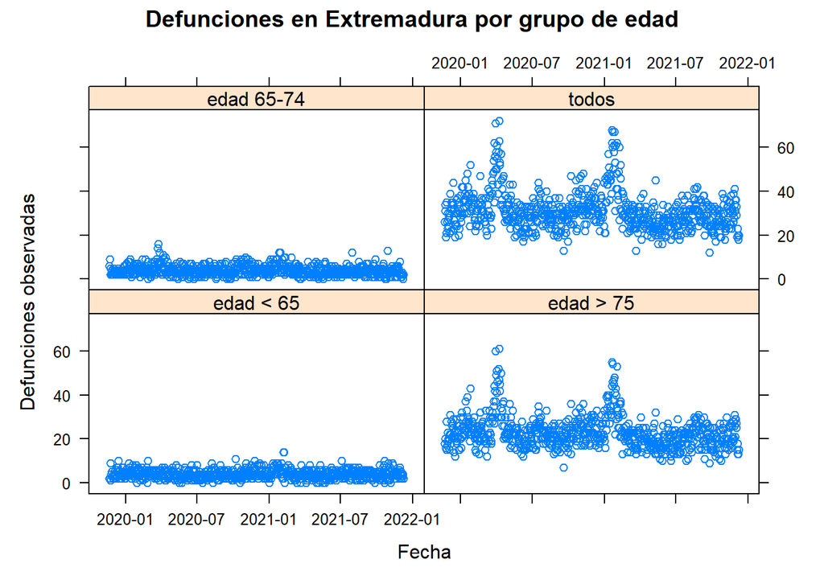

```r
#  Tras instalar lattice

library(lattice) # Se basa en una versión mejorada de las gráficas por defecto de R, pero destaca por la simplicidad a la hora de crear gráficas multivariable. También permite crear gráficas "trellis" que representan una variable o relación entre varias (estando esta representación condicionada a su vez por una o más variables).

xyplot(defunciones_observadas ~ fecha_defuncion | nombre_gedad, data = extremadura_gedad_momo_iscii, main="Defunciones en Extremadura por grupo de edad", ylab = "Defunciones observadas", xlab="Fecha")
```

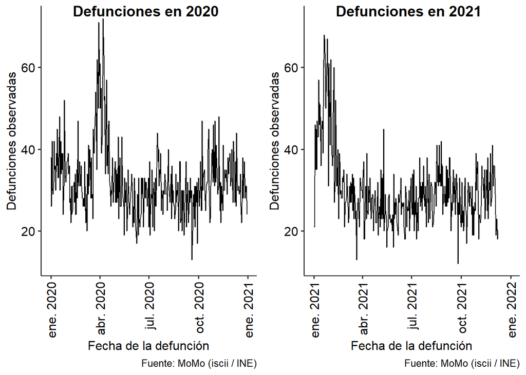

```r
# Ya habíamos utilizado ggpubr antes

library(ggpubr)

theme_set(theme_pubr())

plot_extremadura_momo_iscii_a <- ggplot(extremadura_momo_iscii, aes(x = fecha_defuncion, y = defunciones_observadas)) + geom_line() + scale_x_date(limits = as.Date(c("2020-01-01","2020-12-30")))+ theme(axis.text.x = element_text(angle = 90, vjust = 0.5, hjust=1)) + labs(caption = "Fuente: MoMo (iscii / INE)", x = "Fecha de la defunción", y = "Defunciones observadas")
plot_extremadura_momo_iscii_b <- ggplot(extremadura_momo_iscii, aes(x = fecha_defuncion, y = defunciones_observadas)) + geom_line() + scale_x_date(limits = as.Date(c("2021-01-01","2021-12-30")))+ theme(axis.text.x = element_text(angle = 90, vjust = 0.5, hjust=1)) + labs(caption = "Fuente: MoMo (iscii / INE)", x = "Fecha de la defunción", y = "Defunciones observadas")

plot_extremadura_momo_iscii_combined <- ggarrange(plot_extremadura_momo_iscii_a, plot_extremadura_momo_iscii_b, labels = c("Defunciones en 2020", "Defunciones en 2021"), ncol = 2, nrow = 1)  #Juntamos las dos gráficas que hemos creado en una sola

plot_extremadura_momo_iscii_combined
```

## Estudio de la pandemia en Canarias

Para estudiar la pandemia en cada comunidad autónoma voy a reutilizar mi código, ya que mantendré el nombre de las variables al filtrar los datos para comunidad desde los dataframe iniciales. Los nombres de los dataframes contendran “canarias” o “cn” en lugar de “esp”.

Filtramos los datos.

```r
canarias_casos_diag_ccaa <- filter(casos_diag_ccaa, ccaa_iso == "CN")

canarias_casos_hosp_uci <- bind_rows(filter(casos_hosp_uci,provincia_iso == "GC"), filter(casos_hosp_uci,provincia_iso == "TF")) #Unimos en un dataframe los datos de las provincias de la comunidad autónoma
canarias_casos_hosp_uci <- select(canarias_casos_hosp_uci, -sexo, -grupo_edad)

# Si convertimos la variable $fecha en este último dataframe usando as.Date nos problemas, por eso lo pasaremos al formato fecha de lubridate, un paquete que está pensado para que transformar y operar con fechas sea más sencillo. Al ser lubridate del tidyverse podemos utilizarlo con mutate() de dyplr para convertir la columna de fecha a formato fecha sin complicaciones.

library(lubridate) # Al haber instalado tidyverse lubridate debería estar instalado, aunque al hacer library(tidyverse) no se carga.

canarias_casos_hosp_uci <- canarias_casos_hosp_uci %>%
  mutate(fecha = date(fecha)) %>%
  group_by(fecha) %>%
  summarize(num_casos = sum(num_casos), num_hosp = sum(num_hosp), num_uci = sum(num_uci), num_def = sum(num_def))
```

### 1. Evolución diaria de la pandemia en Canarias

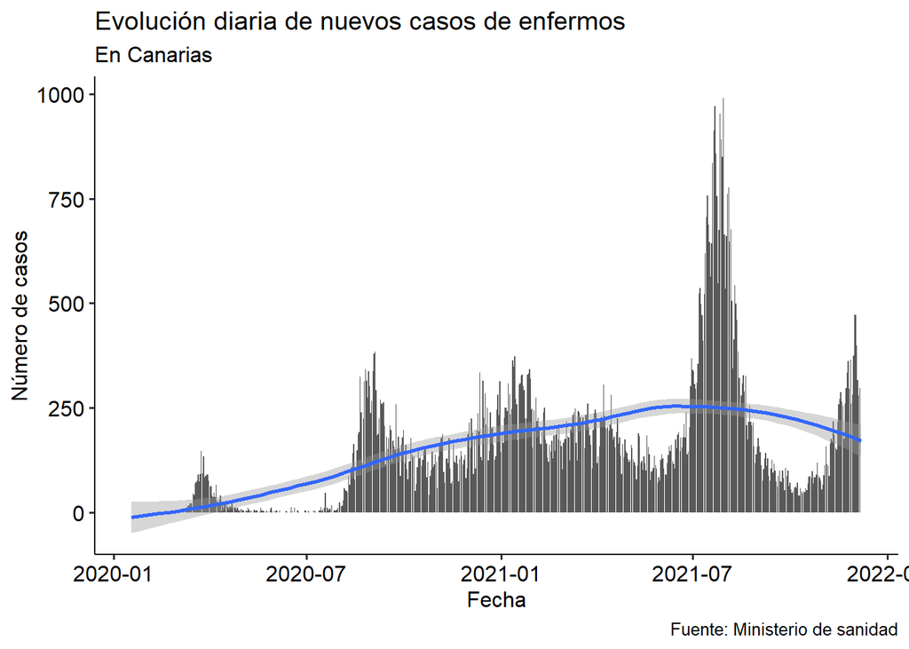

```r
# Utilizamos las variables $fecha (fecha en la que se registra la información) y $num_casos (número de casos nuevos) del dataframe canarias_casos_diag_ccaa que contiene solamente los datos diarios correspondientes a Canarias.

ggplot(canarias_casos_diag_ccaa, aes(x = fecha, y = num_casos)) + geom_col() + labs(title = "Evolución diaria de nuevos casos de enfermos",
              subtitle = "En Canarias",
              caption = "Fuente: Ministerio de sanidad",
              x = "Fecha", y = "Número de casos") + geom_smooth()
```

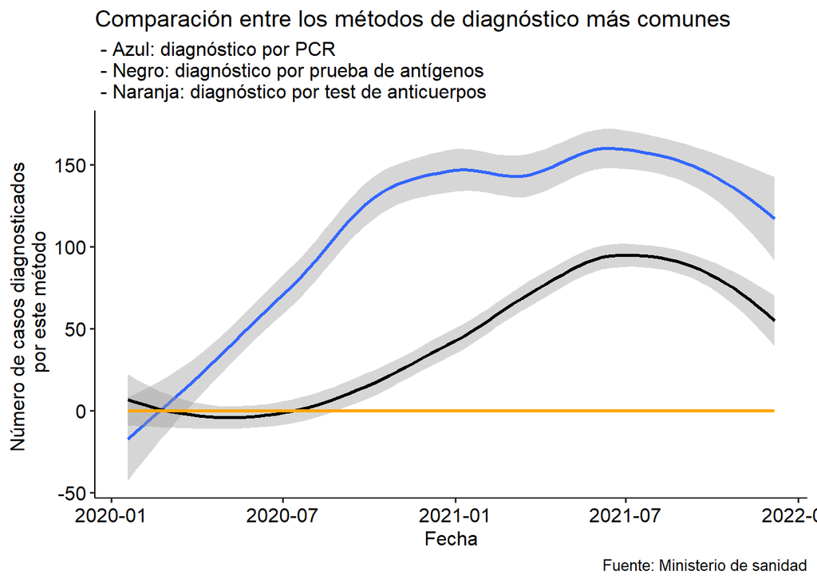

```r
# Utilizamos el mismo dataframe. Tres variables son de nueva introducción: $num_casos_prueba_pcr (número de casos con prueba de laboratorio PCR o técnicas moleculares), $num_casos_prueba_ag (número de casos con prueba de laboratorio de test de detección de antígeno) y $num_casos_prueba_test_ac (Número de casos con prueba de laboratorio de test rápido de anticuerpos).

ggplot(canarias_casos_diag_ccaa, aes(x = fecha, y  = num_casos_prueba_pcr)) + geom_smooth() + geom_smooth(aes(y = num_casos_prueba_ag), color = "black") + geom_smooth(aes(y = num_casos_prueba_test_ac), color = "orange")  + labs(title = "Comparación entre los métodos de diagnóstico más comunes",
              subtitle = " - Azul: diagnóstico por PCR \n - Negro: diagnóstico por prueba de antígenos \n - Naranja: diagnóstico por test de anticuerpos",
              caption = "Fuente: Ministerio de sanidad",
              x = "Fecha", y = "Número de casos diagnosticados \n por este método")
```

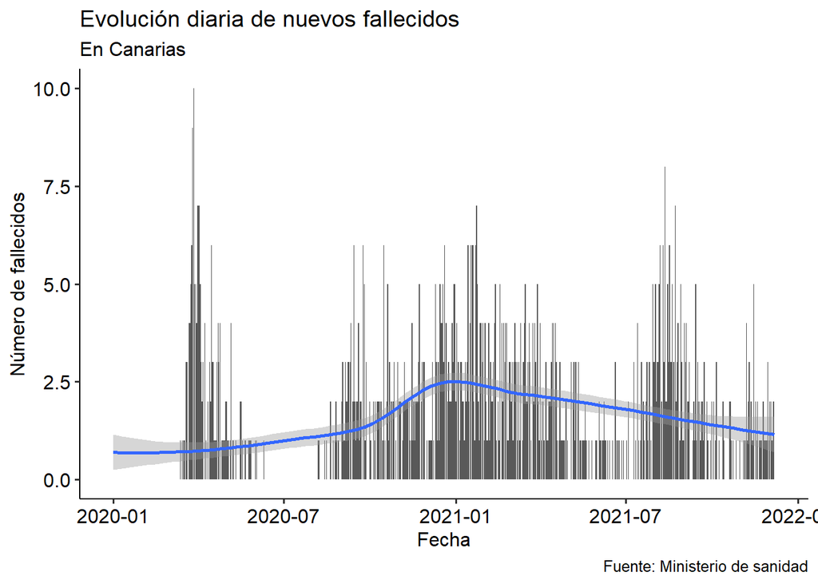

```r
#Utilizamos las variables $fecha (fecha en la que se registra la información) y $num_def (número de defunciones por COVID-19) del dataframe canarias_casos_hosp_uci que contiene solamente los datos diarios correspondientes a Canarias.

ggplot(canarias_casos_hosp_uci, aes(x = fecha, y = num_def)) + geom_col() + labs(title = "Evolución diaria de nuevos fallecidos",
              subtitle = "En Canarias",
              caption = "Fuente: Ministerio de sanidad",
              x = "Fecha", y = "Número de fallecidos") + geom_smooth()
```

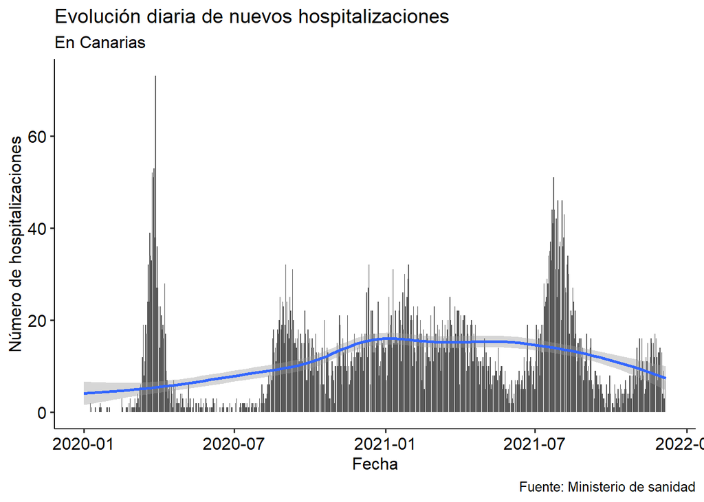

```r
#Utilizamos el dataframe anterior. Introducimos una nueva variable: $num_hosp (número de hospitalizados por COVID-19 diarios)

ggplot(canarias_casos_hosp_uci, aes(x = fecha, y = num_hosp)) + geom_col() + labs(title = "Evolución diaria de nuevos hospitalizaciones",
              subtitle = "En Canarias",
              caption = "Fuente: Ministerio de sanidad",
              x = "Fecha", y = "Número de hospitalizaciones") + geom_smooth()
```

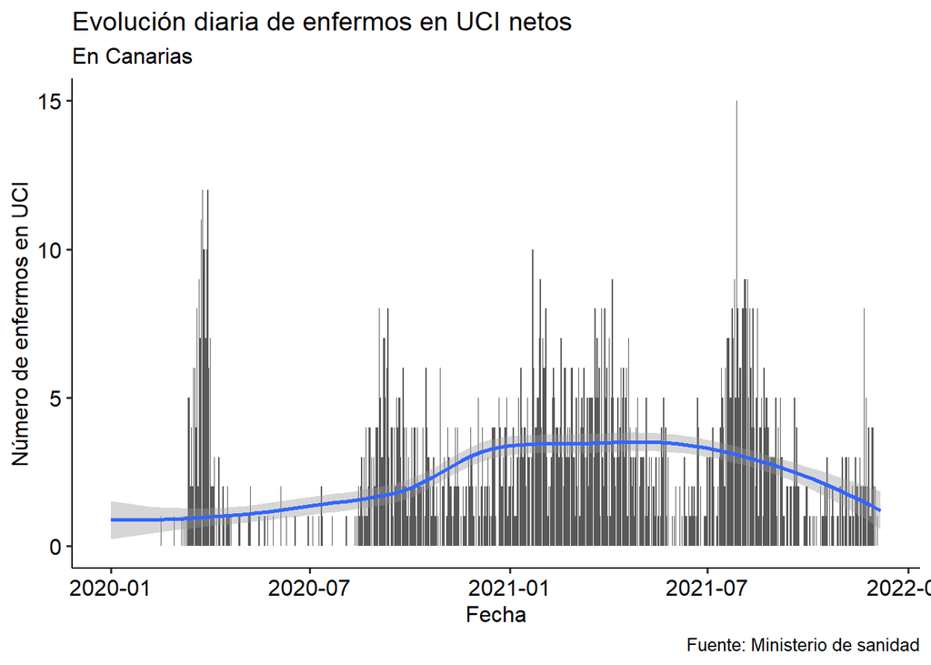

```r
#Utilizamos el dataframe anterior. Introducimos una nueva variable: $num_uci (número de enfermos en UCI por COVID-19 diarios)

ggplot(canarias_casos_hosp_uci, aes(x = fecha, y = num_uci)) + geom_col() + labs(title = "Evolución diaria de enfermos en UCI netos",
              subtitle = "En Canarias",
              caption = "Fuente: Ministerio de sanidad",
              x = "Fecha", y = "Número de enfermos en UCI") + geom_smooth()
```

```r
canarias_casos_diag_ccaa$censo_canarias <- c(2244423) #Introducimos en una variable el censo de Canarias
canarias_casos_diag_ccaa$ev100k_num_casos <- (canarias_casos_diag_ccaa$num_casos * 100000) / canarias_casos_diag_ccaa$censo_canarias #Calculamos el número de casos por 100 000 habitantes
```

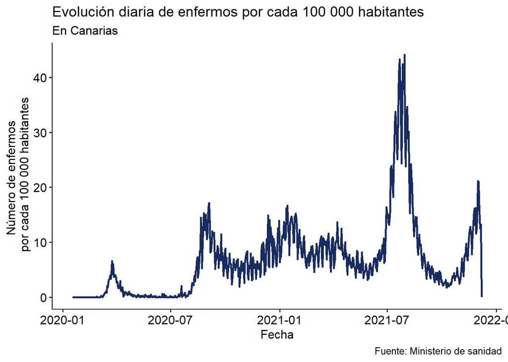

```r
ggplot(canarias_casos_diag_ccaa, aes(x = fecha, y = ev100k_num_casos)) + geom_line(size = 1, color = "#182C61") + labs(title = "Evolución diaria de enfermos por cada 100 000 habitantes",
              subtitle = "En Canarias",
              caption = "Fuente: Ministerio de sanidad",
              x = "Fecha", y = "Número de enfermos \n por cada 100 000 habitantes")
```

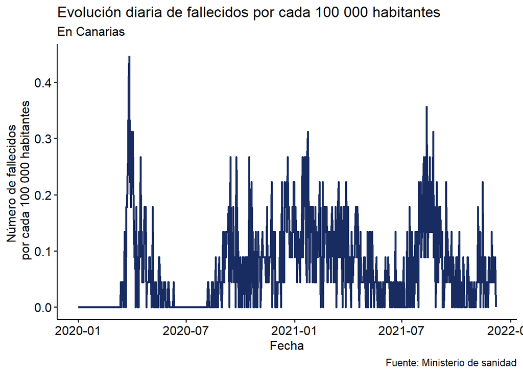

```r
canarias_casos_hosp_uci$censo_canarias <- c(2244423) #Introducimos en una variable el censo de Canarias
canarias_casos_hosp_uci$ev100k_num_def <- (canarias_casos_hosp_uci$num_def * 100000) / canarias_casos_hosp_uci$censo_canarias #Calculamos el número de fallecidos por 100 000 habitantes


ggplot(canarias_casos_hosp_uci, aes(x = fecha, y = ev100k_num_def)) + geom_line(size = 1, color = "#182C61") + labs(title = "Evolución diaria de fallecidos por cada 100 000 habitantes",
              subtitle = "En Canarias",
              caption = "Fuente: Ministerio de sanidad",
              x = "Fecha", y = "Número de fallecidos \n por cada 100 000 habitantes")
```

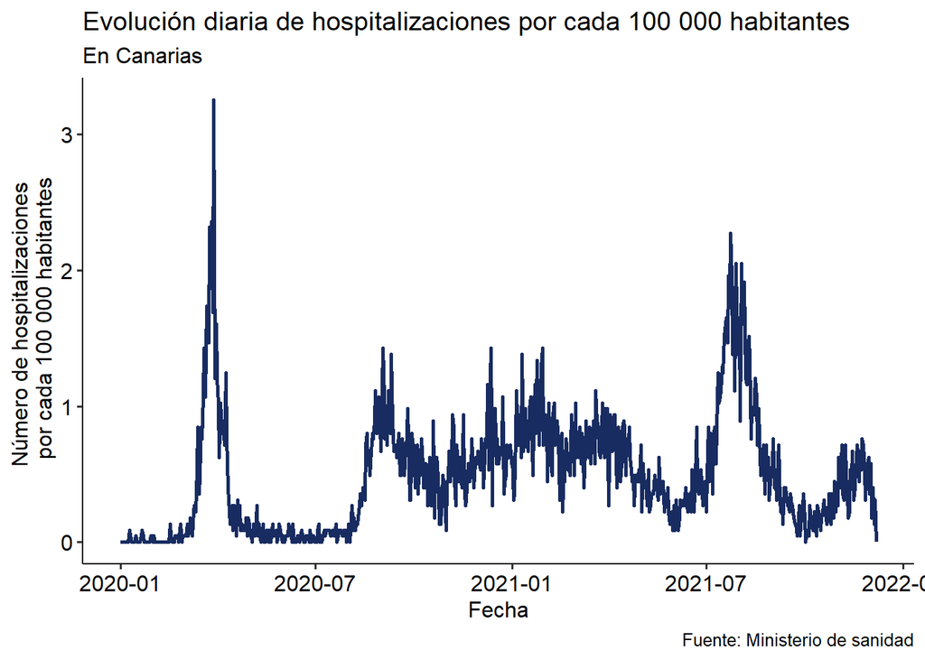

```r
canarias_casos_hosp_uci$ev100k_num_hosp <- (canarias_casos_hosp_uci$num_hosp * 100000) / canarias_casos_hosp_uci$censo_canarias #Calculamos el número de hospitalizados por 100 000 habitantes


ggplot(canarias_casos_hosp_uci, aes(x = fecha, y = ev100k_num_hosp)) + geom_line(size = 1, color = "#182C61") + labs(title = "Evolución diaria de hospitalizaciones por cada 100 000 habitantes",
              subtitle = "En Canarias",
              caption = "Fuente: Ministerio de sanidad",
              x = "Fecha", y = "Número de hospitalizaciones \n por cada 100 000 habitantes")
```

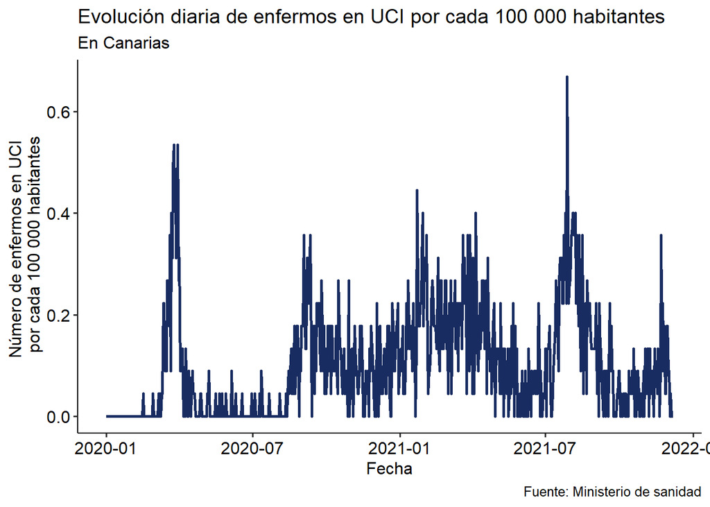

```r
canarias_casos_hosp_uci$ev100k_num_uci <- (canarias_casos_hosp_uci$num_uci * 100000) / canarias_casos_hosp_uci$censo_canarias #Calculamos el número de hospitalizados por 100 000 habitantes


ggplot(canarias_casos_hosp_uci, aes(x = fecha, y = ev100k_num_uci)) + geom_line() + geom_line(size = 1, color = "#182C61") + labs(title = "Evolución diaria de enfermos en UCI por cada 100 000 habitantes",
              subtitle = "En Canarias",
              caption = "Fuente: Ministerio de sanidad",
              x = "Fecha", y = "Número de enfermos en UCI \n por cada 100 000 habitantes")
```

```r
#Creamos una columna de acumulados para cada variable
canarias_casos_diag_ccaa$acum_num_casos <- cumsum(canarias_casos_diag_ccaa$num_casos)
canarias_casos_hosp_uci$acum_num_hosp <- cumsum(canarias_casos_hosp_uci$num_hosp)
canarias_casos_hosp_uci$acum_num_uci <- cumsum(canarias_casos_hosp_uci$num_uci)
canarias_casos_hosp_uci$acum_num_def <- cumsum(canarias_casos_hosp_uci$num_def)
```

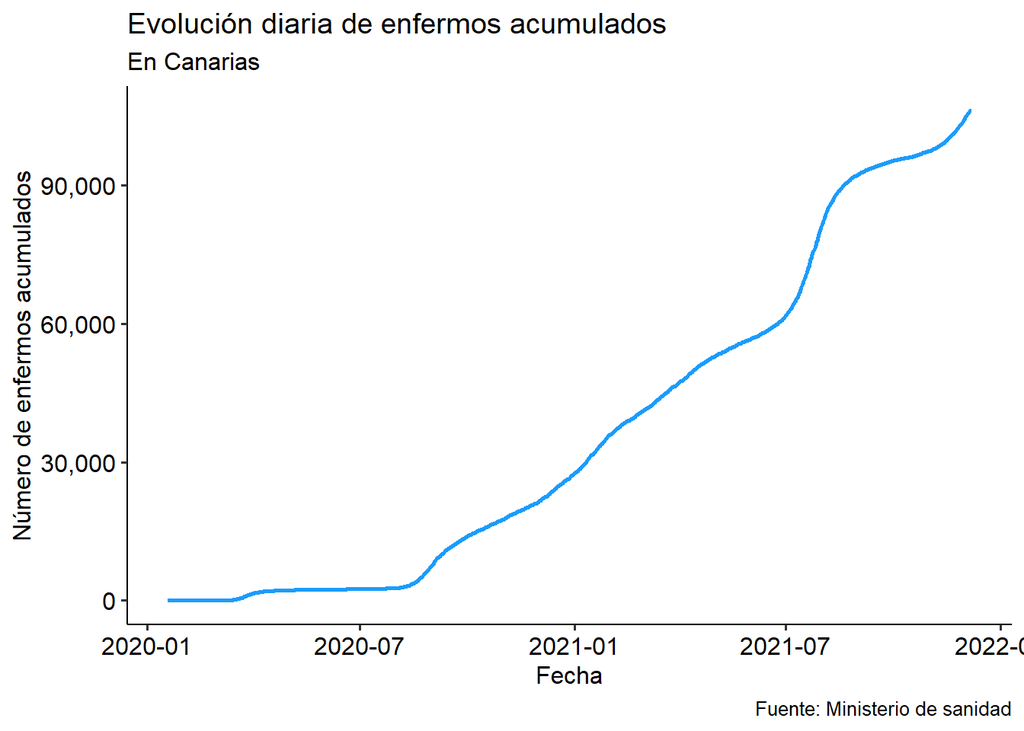

```r
ggplot(canarias_casos_diag_ccaa, aes(x = fecha, y = acum_num_casos)) + geom_line(size = 1, color = "#1B9CFC") + labs(title = "Evolución diaria de enfermos acumulados",
              subtitle = "En Canarias",
              caption = "Fuente: Ministerio de sanidad",
              x = "Fecha", y = "Número de enfermos acumulados") + scale_y_continuous(labels = scales::comma)
```

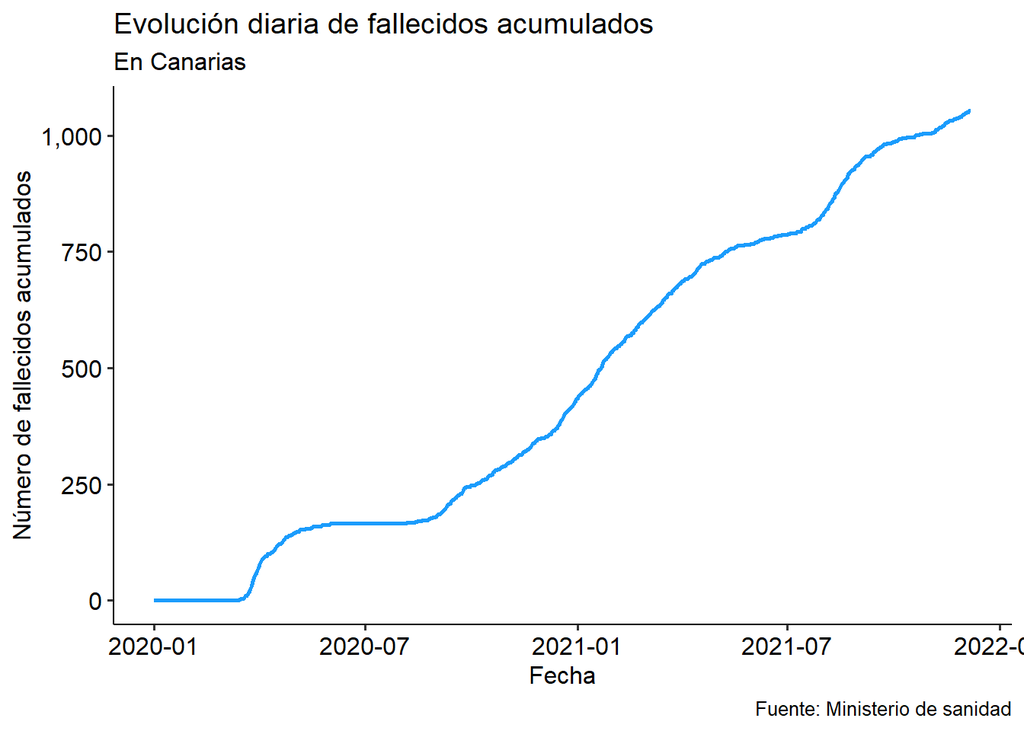

```r
ggplot(canarias_casos_hosp_uci, aes(x = fecha, y = acum_num_def)) + geom_line(size = 1, color = "#1B9CFC") + labs(title = "Evolución diaria de fallecidos acumulados",
              subtitle = "En Canarias",
              caption = "Fuente: Ministerio de sanidad",
              x = "Fecha", y = "Número de fallecidos acumulados") + scale_y_continuous(labels = scales::comma)
```

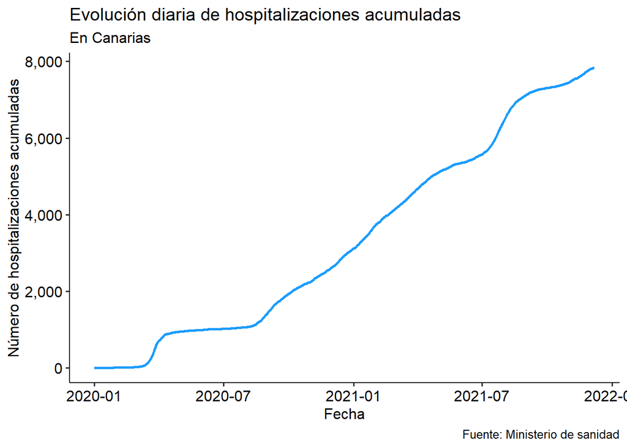

```r
ggplot(canarias_casos_hosp_uci, aes(x = fecha, y = acum_num_hosp)) + geom_line(size = 1, color = "#1B9CFC") + labs(title = "Evolución diaria de hospitalizaciones acumuladas",
              subtitle = "En Canarias",
              caption = "Fuente: Ministerio de sanidad",
              x = "Fecha", y = "Número de hospitalizaciones acumuladas") + scale_y_continuous(labels = scales::comma)
```

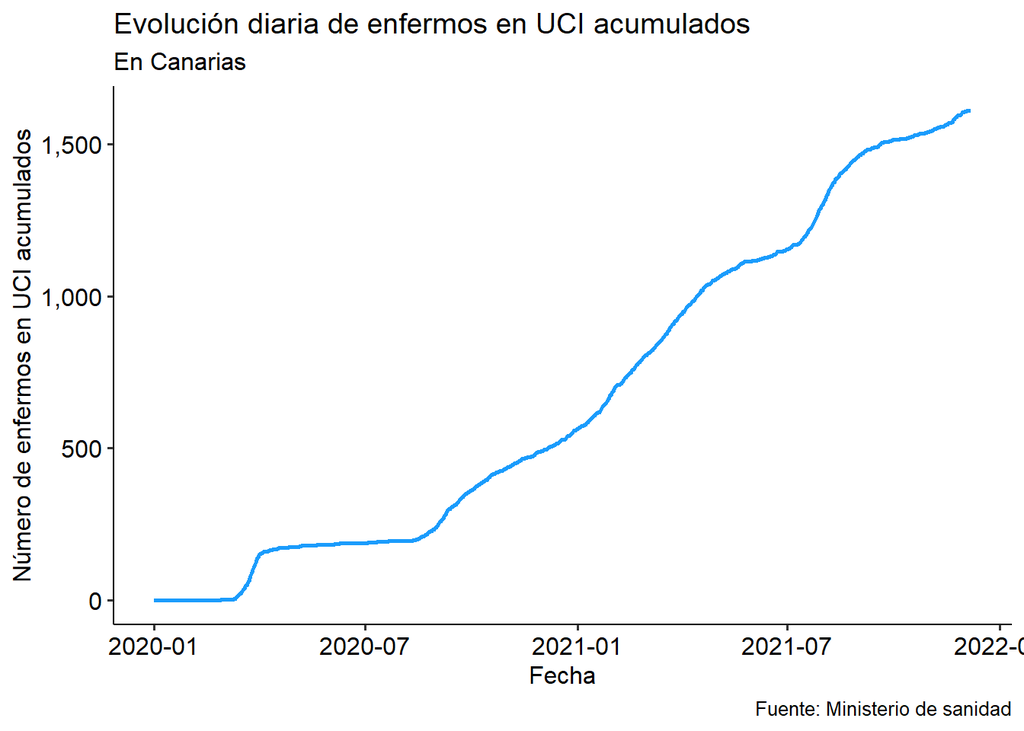

```r
ggplot(canarias_casos_hosp_uci, aes(x = fecha, y = acum_num_uci)) + geom_line(size = 1, color = "#1B9CFC") + labs(title = "Evolución diaria de enfermos en UCI acumulados",
              subtitle = "En Canarias",
              caption = "Fuente: Ministerio de sanidad",
              x = "Fecha", y = "Número de enfermos en UCI acumulados") + scale_y_continuous(labels = scales::comma)
```

### 2. Incidencia acumulada de la pandemia en Canarias

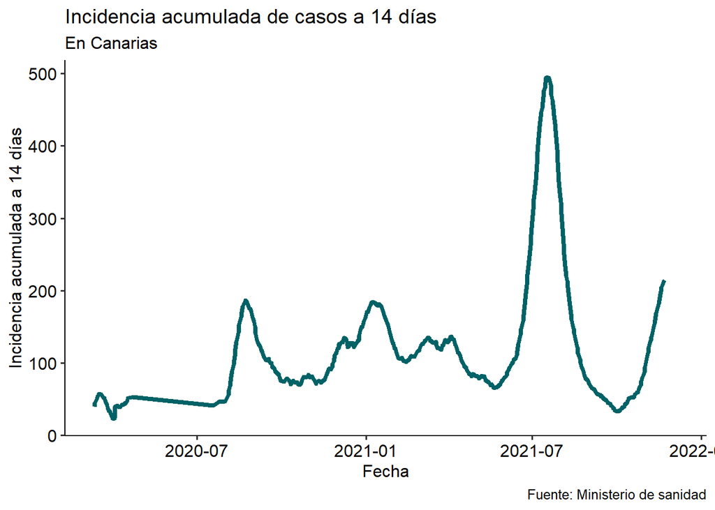

```r
# En la función, t es el número de días transcurridos desde el primer día existente en el dataframe y n el número de días para el que hacer la incidencia acumulada.
iacumuladacn <- function(t, n) {(((cn_incidencia_acumulada_a$acum_num_casos[t]-cn_incidencia_acumulada_a$acum_num_casos[cn_incidencia_acumulada_a$num_fila - n])/cn_incidencia_acumulada_a$censo_canarias)*100000)}

cn_incidencia_acumulada_a <- canarias_casos_diag_ccaa
cn_incidencia_acumulada_a$censo_canarias <- c(2244423)
cn_incidencia_acumulada_a <- filter(cn_incidencia_acumulada_a, num_casos > 15)
cn_incidencia_acumulada_a <- cn_incidencia_acumulada_a %>% mutate(num_fila = c(15:(n()+14))) #Creamos una columna que contenga números enteros ordenados desde n hasta llenar la última fila del dataframe

# Suelo utilizar el operador $ para redefinir variables pero en este caso no me queda otra opción que utilizar mutate() de dplyr porque la función n() para introducir los números de fila solamente funciona en las funciones de dplyr.

cn_incidencia_acumulada_a$incidencia_acumulada <- iacumuladacn(cn_incidencia_acumulada_a$num_fila, 14)

ggplot(cn_incidencia_acumulada_a, aes(x = fecha, y = incidencia_acumulada)) + geom_line(size = 1.5, color = "#006266") + labs(title = "Incidencia acumulada de casos a 14 días",
              subtitle = "En Canarias",
              caption = "Fuente: Ministerio de sanidad",
              x = "Fecha", y = "Incidencia acumulada a 14 días")
```

**Observaciones sobre la gráfica :** El pico más grande de la incidencia acumulada a 14 días en Canarias se ha producido en una fecha significativamente más reciente si comparamos con las gráficas de Extremadura y España.

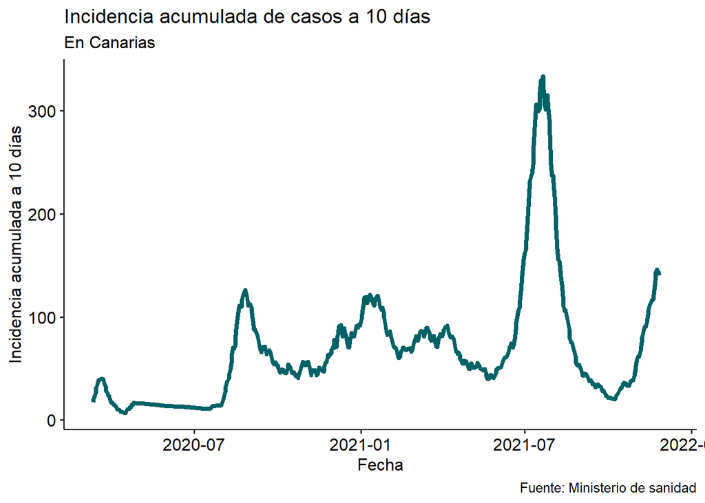

```r
# En la función, t es el número de días transcurridos desde el primer día existente en el dataframe y n el número de días para el que hacer la incidencia acumulada.
iacumuladacn <- function(t, n) {(((cn_incidencia_acumulada_b$acum_num_casos[t]-cn_incidencia_acumulada_b$acum_num_casos[cn_incidencia_acumulada_b$num_fila - n])/cn_incidencia_acumulada_b$censo_canarias)*100000)}

cn_incidencia_acumulada_b <- canarias_casos_diag_ccaa
cn_incidencia_acumulada_b$censo_canarias <- c(2244423)
cn_incidencia_acumulada_b <- filter(cn_incidencia_acumulada_b, num_casos > 10)
cn_incidencia_acumulada_b <- cn_incidencia_acumulada_b %>% mutate(num_fila = c(10:(n()+9))) #Creamos una columna que contenga números enteros ordenados desde n hasta llenar la última fila del dataframe

# Suelo utilizar el operador $ para redefinir variables pero en este caso no me queda otra opción que utilizar mutate() de dplyr porque la función n() para introducir los números de fila solamente funciona en las funciones de dplyr.

cn_incidencia_acumulada_b$incidencia_acumulada <- iacumuladacn(cn_incidencia_acumulada_b$num_fila, 10)

ggplot(cn_incidencia_acumulada_b, aes(x = fecha, y = incidencia_acumulada)) + geom_line(size = 1.5, color = "#006266") + labs(title = "Incidencia acumulada de casos a 10 días",
              subtitle = "En Canarias",
              caption = "Fuente: Ministerio de sanidad",
              x = "Fecha", y = "Incidencia acumulada a 10 días")
```

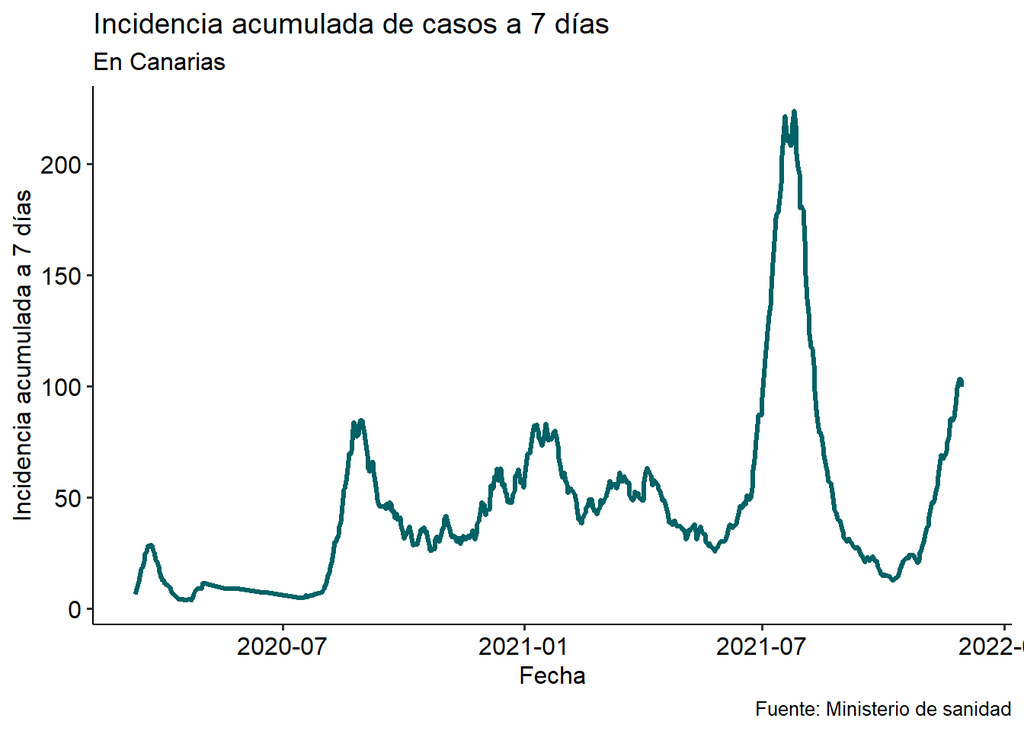

```r
# En la función, t es el número de días transcurridos desde el primer día existente en el dataframe y n el número de días para el que hacer la incidencia acumulada.
iacumuladacn <- function(t, n) {(((cn_incidencia_acumulada_c$acum_num_casos[t]-cn_incidencia_acumulada_c$acum_num_casos[cn_incidencia_acumulada_c$num_fila - n])/cn_incidencia_acumulada_c$censo_canarias)*100000)}

cn_incidencia_acumulada_c <- canarias_casos_diag_ccaa
cn_incidencia_acumulada_c$censo_canarias <- c(2244423)
cn_incidencia_acumulada_c <- filter(cn_incidencia_acumulada_c, num_casos > 7)
cn_incidencia_acumulada_c <- cn_incidencia_acumulada_c %>% mutate(num_fila = c(7:(n()+6))) #Creamos una columna que contenga números enteros ordenados desde n hasta llenar la última fila del dataframe

# Suelo utilizar el operador $ para redefinir variables pero en este caso no me queda otra opción que utilizar mutate() de dplyr porque la función n() para introducir los números de fila solamente funciona en las funciones de dplyr.

cn_incidencia_acumulada_c$incidencia_acumulada <- iacumuladacn(cn_incidencia_acumulada_c$num_fila, 7)

ggplot(cn_incidencia_acumulada_c, aes(x = fecha, y = incidencia_acumulada)) + geom_line(size = 1.2, color = "#006266") + labs(title = "Incidencia acumulada de casos a 7 días",
              subtitle = "En Canarias",
              caption = "Fuente: Ministerio de sanidad",
              x = "Fecha", y = "Incidencia acumulada a 7 días")
```

### 3. Datos de vacunación en Canarias

```r
canarias_datosVacunacionGit <- datosVacunacionGit %>% filter(cod_ine == "5") %>% select(-ccaa, -cod_ine, -fecha_de_la_ultima_vacuna_registrada)

# Incorporamos la columna de dosis administradas diarias

canarias_datosVacunacionGit$dosis_administradas_diarias <- abs(canarias_datosVacunacionGit$dosis_administradas - lag(canarias_datosVacunacionGit$dosis_administradas, 1))
canarias_datosVacunacionGit$dosis_administradas_diarias[1] <- 0 # Sustituimos el valor nulo inicial por 0
```

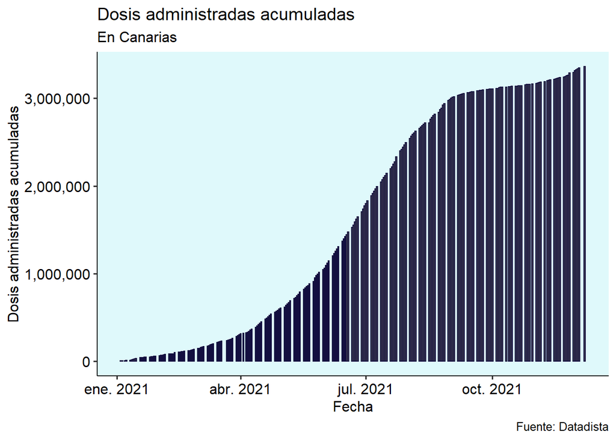

```r
ggplot(canarias_datosVacunacionGit, aes(x = fecha_publicacion, y = dosis_administradas)) + geom_col(color = "#130f40") + theme(panel.background = element_rect(fill = "#dff9fb", colour = NA), panel.grid.major = element_blank(), panel.grid.minor = element_blank()) + labs(title = "Dosis administradas acumuladas",
              subtitle = "En Canarias",
              caption = "Fuente: Datadista",
              x = "Fecha", y = "Dosis administradas acumuladas")  + scale_y_continuous(labels = scales::comma)
```

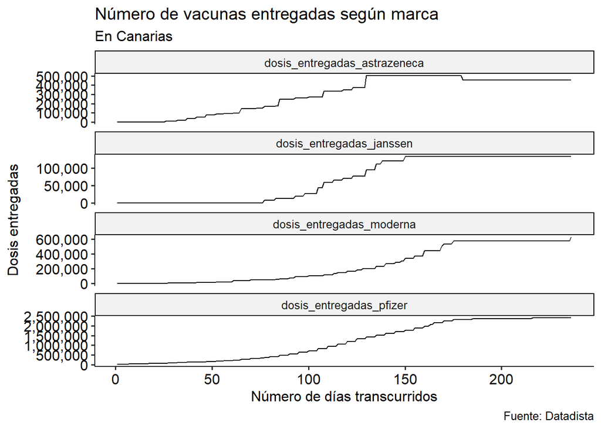

```r
# Después de instalar ggfortify.

library(ggfortify) # Ampliación de las funciones de ggplot2, incluyendo la función que nos hace falta: autoplot()

# Creamos un nuevo objeto basado en tiempo, esto es un cierto número de observaciones distribuidas a lo largo de un período de tiempo determinado y con una frecuencia definida. En este caso utilizaré un objeto ts para el que no será necesario instalar ningún otro paquete. Además puedo convertir mis variables del dataframe de vacunación a objetos ts con la función as.ts(), ya que están basadas en tiempo y son numéricas.

ts_canarias_datosVacunacionGit <- as.ts(select(canarias_datosVacunacionGit, dosis_entregadas_astrazeneca, dosis_entregadas_janssen, dosis_entregadas_moderna, dosis_entregadas_pfizer)) #En el objeto ts solamente estarán las variables de dosis entregadas según la marca.
autoplot(ts_canarias_datosVacunacionGit) + labs(title = "Número de vacunas entregadas según marca",
              subtitle = "En Canarias",
              caption = "Fuente: Datadista",
              x = "Número de días transcurridos", y = "Dosis entregadas") + scale_y_continuous(labels = scales::comma)
```

```r
# Después de instalar dygraphs y xts

library(dygraphs) # Introduce la librería de dygraphs para Javascript en R, permitiendo crear gráficas interactivas a partir de objetos xts.
library(xts) # Permite crear objetos xts.
xts_canarias_datosVacunacionGit <- xts(x = canarias_datosVacunacionGit$dosis_administradas_diarias, order.by = canarias_datosVacunacionGit$fecha_publicacion)


dygraph(xts_canarias_datosVacunacionGit, main = "Evolución diaria de la vacunación en Canarias") %>% dyRangeSelector()
```

[interactive chart not shown]

```r
# En la siguiente gráfica se puede hacer hover sobre los datos para conocer el número de vacunados diarios en un momento determinado. Se puede ajustar el rango de fechas que toma el eje x moviendo los extremos de la barra que hay bajo la gráfica.
```

```r
# Después de instalar fuzzyjoin

library(fuzzyjoin)

cn_vacunacionVScasos <- data.frame("fecha" = canarias_casos_hosp_uci$fecha, "num_casos" = canarias_casos_hosp_uci$num_casos) # Creamos el nuevo dataframe que contiene los datos de enfermos acumulados y la columna de fechas de ese dataframe.

cn_vacunacionVScasos <- cn_vacunacionVScasos %>%
  stringdist_inner_join(canarias_datosVacunacionGit, by = c("fecha" = "fecha_publicacion"), max_dist = 0, distance_col = "distance")
# Al establecer max_dist = 0 solo las coincidencias exactas con la fecha se han copiado. Además he incluido la columna "distance" para poder detectar errores en el caso de que los hubiera, ya que el valor de esta variable siempre debe ser 0 en este caso.

cn_vacunacionVScasos$censo_canarias <- c(2244423) #Introducimos el censo de Canarias

cn_vacunacionVScasos <- cn_vacunacionVScasos %>% mutate(enfermos_diarios_por_100hab = (num_casos*100) / censo_canarias, porcentaje_vacunados = (personas_con_pauta_completa/censo_canarias)*100) # Creamos las variables que vamos a utilizar en la gráfica mediante operaciones con otras variables.
```

En Canarias cambiamos los enfermos por 100 000 habitantes a enfermos por cada 100 habitantes.

```r
# Tras haber instalado plotly

library(plotly) # Plotly utiliza la librería plotly.js de Javascript para crear los gráficos interactivos. Ofrece muchas posibilidades, como la creación de animaciones o controles personalizados, por eso es una muy buena opción para las aplicaciones con Shiny.

plotly_cn_vacunacionVScasos <- ggplot(cn_vacunacionVScasos, aes(x = fecha, y = enfermos_diarios_por_100hab)) + geom_line() + geom_line(aes(y = porcentaje_vacunados), color = "red", linetype = "solid") + labs(title = "% de vacunados en comparación con el nº de enfermos por 100 habitantes",
              subtitle = "",
              caption = "Fuente: Ministerio de sanidad y Datadista",
              x = "Fecha", y="") # Creamos la gráfica en ggplot2
plotly_cn_vacunacionVScasos <- ggplotly(plotly_cn_vacunacionVScasos) %>% layout(hovermode = 'x') # La pasamos a gráfica de plotly y establecemos la opción de comparar los datos en la y por defecto.
plotly_cn_vacunacionVScasos
```

[interactive chart not shown]

```r
#Los gráficos de plotly permiten hacer zoom en cualquier parte del gráfico para observar las tendencias con más detenimiento. Al hacer hover aparece la leyenda. Además, se puede descargar el gráfico en png después de modificarlo haciendo clic en el botón de la cámara en la barra de herramientas de la esquina superior derecha.
```

### 4. Datos de la mortalidad general en Canarias

```r
canarias_gedad_momo_iscii <- filter(momo_iscii, nombre_ambito == "Canarias", nombre_sexo == "todos") # Filtramos para conseguir los datos de Canarias, dejando el grupo de edad para la primera gráfica

# Ahora filtramos de nuevo el dataframe para obtener los datos para todos los grupos de edad (segunda gráfica).
canarias_momo_iscii <- filter(momo_iscii, nombre_ambito == "Canarias", nombre_sexo == "todos", nombre_gedad == "todos")

#Utilizaremos las variables fecha_defuncion (fecha de defunción) y defunciones_observadas (defunciones en el día en cuestión)
```

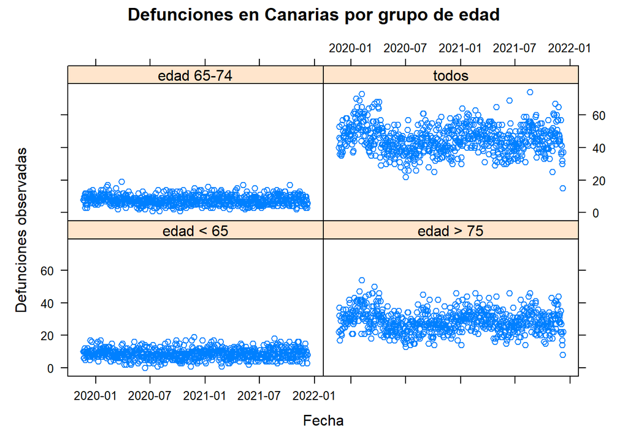

```r
#  Tras instalar lattice

library(lattice) # Se basa en una versión mejorada de las gráficas por defecto de R, pero destaca por la simplicidad a la hora de crear gráficas multivariable. También permite crear gráficas "trellis" que representan una variable o relación entre varias (estando esta representación condicionada a su vez por una o más variables).

xyplot(defunciones_observadas ~ fecha_defuncion | nombre_gedad, data = canarias_gedad_momo_iscii, main="Defunciones en Canarias por grupo de edad", ylab = "Defunciones observadas", xlab="Fecha")
```

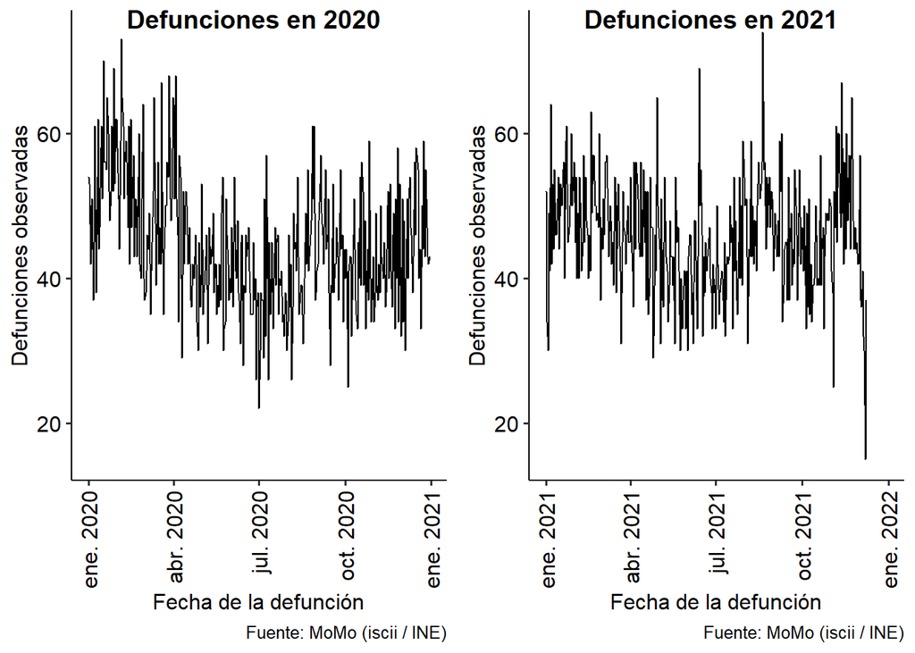

```r
# Ya habíamos utilizado ggpubr antes

library(ggpubr)

theme_set(theme_pubr())

plot_canarias_momo_iscii_a <- ggplot(canarias_momo_iscii, aes(x = fecha_defuncion, y = defunciones_observadas)) + geom_line() + scale_x_date(limits = as.Date(c("2020-01-01","2020-12-30")))+ theme(axis.text.x = element_text(angle = 90, vjust = 0.5, hjust=1)) + labs(caption = "Fuente: MoMo (iscii / INE)", x = "Fecha de la defunción", y = "Defunciones observadas")
plot_canarias_momo_iscii_b <- ggplot(canarias_momo_iscii, aes(x = fecha_defuncion, y = defunciones_observadas)) + geom_line() + scale_x_date(limits = as.Date(c("2021-01-01","2021-12-30")))+ theme(axis.text.x = element_text(angle = 90, vjust = 0.5, hjust=1)) + labs(caption = "Fuente: MoMo (iscii / INE)", x = "Fecha de la defunción", y = "Defunciones observadas")

plot_canarias_momo_iscii_combined <- ggarrange(plot_canarias_momo_iscii_a, plot_canarias_momo_iscii_b, labels = c("Defunciones en 2020", "Defunciones en 2021"), ncol = 2, nrow = 1)  #Juntamos las dos gráficas que hemos creado en una sola

plot_canarias_momo_iscii_combined
```

# Conclusiones

Al estudiar la incidencia acumulada, encontramos diferencias entre las de España y las comunidades autónomas. Los picos de la incidencia acumulada a 14 días en España son 10, y el hecho de que la incidencia haya bajado en la mayoría de los casos se debe a las acciones que los gobiernos toman para contener la expansión del virus. De esta manera, como cada comunidad autónoma tiene restricciones distintas, la incidencia acumulada a 14 días varía con respecto a España en Extremadura y Canarias. En Extremadura se observan 7 picos y en Canarias 9. Llama la atención que en Canarias el mayor pico de la incidencia acumulada a 14 días se produjo en el segundo semestre del 2021, en verano. Esto último podría deberse al turismo de verano.

En cuanto a la vacunación, podemos ver como las vacunas recibidas de forma más consistente y numerosa en todos los casos han sido las de Pfizer y Moderna. Haciendo referencia a la gráfica que compara los enfermos con la evolución de la vacunación en España, podemos ver como en mayo de 2021 por primera vez la curva de vacunación supera a la de enfermos por 100 000 habitantes. No obstante, en verano la curva de enfermos supera a la curva de vacunación (como ya se mencionó en Canarias, podría estar relacionado con el turismo de verano). En julio la curva de vacunación vuelve a estar por encima de la de enfermos, y por ahora esta tendencia se esta manteniendo hasta el día de hoy. Este tipo de gráfica para cada comunidad autónoma también evidencia la evolución de la vacunación si ampliamos la gráfica interactiva, aunque es más complicado de determinar al haber menos casos diarios en comparación al porcentaje de vacunados.

En cuanto a los datos de mortalidad, en España y Extremadura podemos observar como existe un claro aumento de las defunciones en abril de 2020 (si lo comparamos con abril de 2021).

Finalmente, podemos observar que la vacunación ha favorecido el descenso del número de enfermos de COVID-19 en la mayoría de grupos de edad. No obstante, cuando observamos la gráfica de la comparación de enfermos por grupos de edad en España se aprecia como el grupo de edad de 0 a 9 años se ha mantenido en cifras similares. Esto podría ser debido a que no están vacunados, aunque la campaña de vacunación para las personas pertenecientes a este grupo de edad ya es un tema de actualidad en los informativos y se empezará a vacunar en este grupo de edad. Esto debería comprobarse revisando de nuevo los datos cuando los individuos de este grupo de edad lleguen a las dosis necesarias para la inmunidad (dependiendo de la vacuna administrada).

# Referencias

Información del help del R.

**Citas**  
1- [Información sobre la utilidad de la incidencia acumulada](https://www.redaccionmedica.com/recursos-salud/faqs-covid19/que-es-la-incidencia-acumulada-covid)

**Información utilizada sobre los dataframes**  
[Referencia sobre los dataframes del Ministerio de Sanidad](https://cnecovid.isciii.es/covid19/resources/metadata_diag_ccaa_decl_prov_edad_sexo.pdf)  
[Referencia sobre los dataframes de Datadista](https://github.com/datadista/datasets/blob/master/COVID%2019/readme.md)  
[Referencia sobre los dataframes de mortalidad](https://momo.isciii.es/public/momo/dashboard/momo_dashboard.html#datos)

**Información utilizada sobre los paquetes y librerías**  
[Comandos de knitr para R Markdown](https://yihui.org/knitr/options/)  
[Información y ejemplos de todos los paquetes de tidyverse](https://www.tidyverse.org/packages/)  
[Comandos principales de lubridate](https://rawgit.com/rstudio/cheatsheets/main/lubridate.pdf)  
[Funciones y ejemplos del paquete lattice](http://www.sthda.com/english/wiki/lattice-graphs)  
[Gráficas interactivas fundamentales de plotly](https://plotly.com/r/plotly-fundamentals/)  
[Gráfica con dygraphs en la documentación de “htmlwidgets”](https://www.htmlwidgets.org/showcase_dygraphs.html)  
[Hoja de comandos comunes para personalizar gráficas de ggplot](http://www.sthda.com/english/articles/32-r-graphics-essentials/125-ggplot-cheat-sheet-for-great-customization/)  
[Documentación de fuzzyjoin](https://cran.r-project.org/web/packages/fuzzyjoin/readme/README.html)  
[Documentación de dygraphs, donde también se mencionan los objetos xts](https://rstudio.github.io/dygraphs/)  
[Ejemplos de CRAN para trabajar con ggfortify::autoplot() y objetos basados en observaciones por tiempo](https://cran.r-project.org/web/packages/ggfortify/vignettes/plot_ts.html)  
[Temas a definir en ggpubr](https://rdrr.io/cran/ggpubr/man/theme_pubr.html)  
[Combinar gráficos de ggplot con ggpubr](http://www.sthda.com/english/articles/32-r-graphics-essentials/126-combine-multiple-ggplots-in-one-graph/)

**Información leida proveniente de foros**  
[Forma “tidy” de unir dos columnas encajando fechas inexactas](https://community.rstudio.com/t/tidy-way-to-range-join-tables-on-an-interval-of-dates/7881/2)